# Kids Feet

## Background

Jared is a consultant working for a shoe making company. A recent push has been made to understand more the variation of childrens feet, specifically between boys and girls. This is to better help the company when it comes to designing comfortable and affordable shoes. Using a dataset collected by statistician Mary C Meyer, regarding 4th grade children, an analysis was conducted to determine the answer to Jareds question. Are boys feet bigger than girls feet because of length or width, or both.

## Analysis

To test to see the differnces in foot size this analysis will be split into two sections, one for foot width, and the other for foot length. In both sections a hypothesis, normalization graphs, and a t.Test will be presented.

#### Foot Width

1. Are boys feet bigger because of width?

$$H_0: \mu_{\text{BoyW}} - \mu_{\text{GirlsW}} = 0$$

$$H_a: \mu_{\text{BoyW}} - \mu_{\text{GirlsW}} ≠ 0$$

$$\text{Level of Significance} = .05$$

**Testing Normalization of Data**

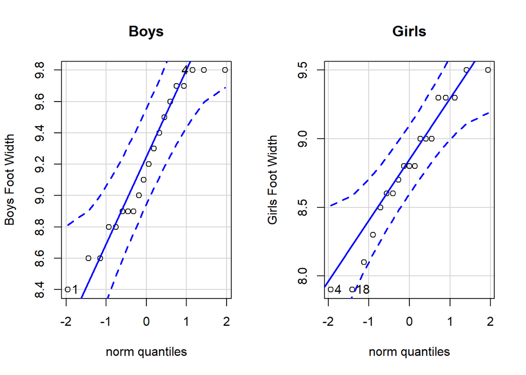

```r
boysfeet <- subset(KidsFeet, sex == "B")
girlsfeet <- subset(KidsFeet, sex == "G")

par(mfrow = c(1,2))
qqPlot(boysfeet$width, ylab = "Boys Foot Width", main = "Boys")
qqPlot(girlsfeet$width, ylab = "Girls Foot Width", main = "Girls" )
```

This graph represents testing of the nirmalization of the data making sure it fits the requiremnts for an t-Test. From these graphs we can tell the data is normal.

**t-Test Results:**

```r
pander(t.test(boysfeet$width, girlsfeet$width, mu = 0, alternative = "two.sided", conf.level = .95), use.hyphening = TRUE, split.cells = c(10, 10, 10, 10, 10, 10))
```

Welch Two Sample t-test: `boysfeet$width` and `girlsfeet$width`

| Test statistic | df | P value | Alternative hypothesis | mean of x | mean of y |
| --- | --- | --- | --- | --- | --- |
| 2.674 | 36.28 | 0.01117 * | two.sided | 9.19 | 8.784 |

This chart displays the data from the previous t-Test. With a p-Value of $p = .01117$ can conclude that there is sufficant evidence to reject the null.

#### Foot Length

2. Are boys feet bigger because of Length?

$$H_0: \mu_{\text{BoyL}} - \mu_{\text{GirlsL}} = 0$$

$$H_a: \mu_{\text{BoyL}} - \mu_{\text{GirlsL}} ≠ 0$$

$$\text{Level of Significance} = .05$$

**Testing Normalization of Data**

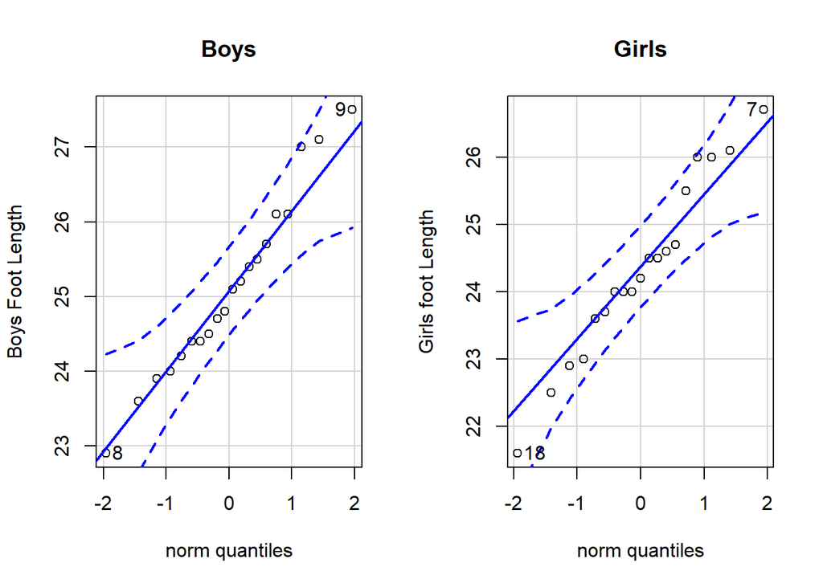

```r
par(mfrow= c(1,2))
qqPlot(boysfeet$length, ylab = "Boys Foot Length", main = "Boys")
qqPlot(girlsfeet$length, ylab = "Girls foot Length", main = "Girls")
```

This graph represents testing of the nirmalization of the data making sure it fits the requiremnts for an t-Test. From these graphs we can tell the data is normal.

**t-Test Results:**

```r
pander(t.test(boysfeet$length, girlsfeet$length, mu = 0, alternative = "two.sided", conf.level = .95), use.hyphening = TRUE, split.cells = c(10, 10, 10, 10, 10, 10))
```

Welch Two Sample t-test: `boysfeet$length` and `girlsfeet$length`

| Test statistic | df | P value | Alternative hypothesis | mean of x | mean of y |
| --- | --- | --- | --- | --- | --- |
| 1.917 | 36.27 | 0.06308 | two.sided | 25.11 | 24.32 |

This chart displays the data from the previous t-Test. With a p-Value of $p = .06308$ can conclude that there is insufficant evidence to reject the null.